# Network Analysis

### Network Analysis

A simple (scalable) network analysis with a focus on the weights between nodes. It makes use of the package *networkx*. Throughout the analysis, I will use the analogy of *shops* and the *owners* of the shops, which can also be another shop, meaning there can be an ultimate owner who sits at the top of what is essentially a tree. Example:

```python
import pandas as pd
data = pd.DataFrame({'shop': ['S1', 'S2', 'S3', 'S1', 'S1', 'S4', 'S2', 'S3'],
                     'owner': ['O1', 'O2', 'S2', 'O3', 'S4', 'O4', 'O5', 'O6']})
data.head(10)
```

|  | shop | owner |
| --- | --- | --- |
| 0 | S1 | O1 |
| 1 | S2 | O2 |
| 2 | S3 | S2 |
| 3 | S1 | O3 |
| 4 | S1 | S4 |
| 5 | S4 | O4 |
| 6 | S2 | O5 |
| 7 | S3 | O6 |

```python
import networkx as nx
def all_descendants_nx():
    DiG = nx.from_pandas_edgelist(data,'owner','shop',
                                  create_using=nx.DiGraph())
    return pd.DataFrame.from_records([(n1,n2) for n1 in DiG.nodes()
        for n2 in nx.ancestors(DiG, n1)], columns=['shop','ult_owners'])
```

Now I simply call the function which will create a new data frame with all the final owners of the shops.

```python
desc_df = all_descendants_nx()
desc_df = desc_df.loc[desc_df.ult_owners.str.startswith("O")]
desc_df.head(10)
```

|  | shop | ult_owners |
| --- | --- | --- |
| 0 | S1 | O3 |
| 1 | S1 | O1 |
| 3 | S1 | O4 |
| 4 | S2 | O5 |
| 5 | S2 | O2 |
| 6 | S3 | O5 |
| 7 | S3 | O2 |
| 9 | S3 | O6 |
| 10 | S4 | O4 |

Finally, I can group by the shops to put all the owners together, and also get the links between them.

```python
desc_df['Links'] = desc_df.shop.astype('str'
                    ) + ' - '+ desc_df.ult_owners.astype('str')
desc_df = desc_df.groupby('shop').agg(lambda x:
                                      sorted(x.tolist())).reset_index()
desc_df.head()
```

|  | shop | ult_owners | Links |
| --- | --- | --- | --- |
| 0 | S1 | [O1, O3, O4] | [S1 - O1, S1 - O3, S1 - O4] |
| 1 | S2 | [O2, O5] | [S2 - O2, S2 - O5] |
| 2 | S3 | [O2, O5, O6] | [S3 - O2, S3 - O5, S3 - O6] |
| 3 | S4 | [O4] | [S4 - O4] |

In fact, if creating the graph means I can plot the result:

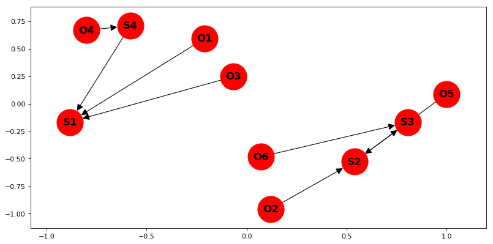

```python
%matplotlib inline
from matplotlib.pyplot import figure
figure(num=None, figsize=(12, 6), dpi=80, facecolor='w', edgecolor='k')
import numpy as np
np.random.seed(1)
G = nx.from_pandas_edgelist(data,'owner','shop',
                                  create_using=nx.DiGraph())
pos=nx.spring_layout(G, k = 0.5, iterations = 20)
node_labels = {node:node for node in G.nodes()}
nx.draw_networkx(G, pos, labels = node_labels, arrowstyle = '-|>',
             arrowsize = 20,  font_size = 15, font_weight = 'bold', node_size = 1500)
```

Graphing in this way makes it easy to see who has ownership of each shop. NB, I can check which shops also have some ownership over other shops like this:

```python
print(set(data.shop) & set(data.owner))
```

```
{'S2', 'S4'}
```

As a next step, I want to introduce percentage shares to the data frame. This example is slightly simplified but with weights added. In this simple example the weights all add to 1.

```python
data = pd.DataFrame({'shop': ['S1', 'S1', 'S1', 'S2', 'S2', 'S3', 'S3', 'S3'],
                     'owner': ['O1', 'O2', 'S2', 'S3', 'O3', 'O4', 'O5', 'O6'],
                     'share': [0.2,   0.2,  0.6,  0.5,  0.5,  0.1,  0.1,  0.8]})
data.head(10)
```

|  | shop | owner | share |
| --- | --- | --- | --- |
| 0 | S1 | O1 | 0.2 |
| 1 | S1 | O2 | 0.2 |
| 2 | S1 | S2 | 0.6 |
| 3 | S2 | S3 | 0.5 |
| 4 | S2 | O3 | 0.5 |
| 5 | S3 | O4 | 0.1 |
| 6 | S3 | O5 | 0.1 |
| 7 | S3 | O6 | 0.8 |

In this example all the shops and owners are connected as part of the same graph. I can draw the graph and add the weights to it:

```
{('O1', 'S1'): Text(0.523397,0.76389,'0.2'),
 ('O2', 'S1'): Text(0.208536,0.671963,'0.2'),
 ('S2', 'S1'): Text(0.456213,0.543579,'0.6'),
 ('S3', 'S2'): Text(0.268799,-0.186819,'0.5'),
 ('O3', 'S2'): Text(0.486679,-0.293083,'0.5'),
 ('O4', 'S3'): Text(-0.221858,-0.219201,'0.1'),
 ('O5', 'S3'): Text(-0.379704,-0.34279,'0.1'),
 ('O6', 'S3'): Text(-0.426816,-0.541575,'0.8')}
```

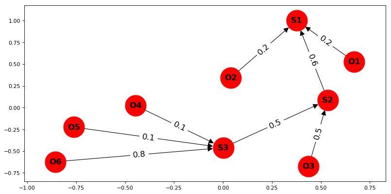

```python
G = nx.from_pandas_edgelist(data,'owner', 'shop', edge_attr = ('share'),
                            create_using=nx.DiGraph())
figure(num=None, figsize=(12, 6), dpi=80, facecolor='w', edgecolor='k')
np.random.seed(4)
pos=nx.spring_layout(G, k = 0.5, iterations = 20)
node_labels = {node:node for node in G.nodes()}
edge_labs = nx.get_edge_attributes(G,'share')
nx.draw_networkx(G, pos, labels = node_labels,
                 arrowstyle = '-|>', edge_labels = edge_labs,
             arrowsize = 20,  font_size = 15,
                 font_weight = 'bold', node_size = 1500)
nx.draw_networkx_edge_labels(G, pos, edge_labels = edge_labs,
                             font_size = 15)
```

The next step is to calcuate the percentage share owned by each owner. For the shops owned by other shops, I need to multiply through the percentages:

```python
owners = set(data['owner'])
shops  = set(data['shop'])
summary = {}
for owner in owners:
    for shop in shops:
        paths = list(nx.all_simple_paths(G, owner, shop))
        if len(paths):
            for path in paths:
                for start, end in zip(path[:-1], path[1:]):
                    summary[(shop, owner)] = summary.get((shop,owner),
                                            1) * G[start][end]['share']

summary = pd.DataFrame.from_dict(summary, orient = 'index',
                                 columns = 'share'.split())
print(summary)
```

```
          share
(S1, O2)   0.20
(S1, S2)   0.60
(S3, O5)   0.10
(S2, O5)   0.05
(S1, O5)   0.03
(S1, O1)   0.20
(S2, S3)   0.50
(S1, S3)   0.30
(S3, O6)   0.80
(S2, O6)   0.40
(S1, O6)   0.24
(S2, O3)   0.50
(S1, O3)   0.30
(S3, O4)   0.10
(S2, O4)   0.05
(S1, O4)   0.03
```

This has created a long data frame giving each combination of owners and shares. I want to get the final ownership for each, and their weights:

```python
# For viewing the whole column
pd.set_option('max_colwidth', -1)
```

```python
# Turn index to column
summary = summary.reset_index()

# Turn into 2 separate stripped columns
summary["index"] = summary["index"].astype(str)
summary['shop'], summary['owner'] = summary['index'
                                    ].str.split(' ', 1).str
summary["shop"] = summary.shop.str.replace('\W', '')
summary["owner"] = summary.owner.str.replace('\W', '')

# Tunr into percentage and add to owners
summary["share"] = summary["owner"] + ": " + (
                         summary["share"]*100).map(str) + "%"

# Keep only final owners
summary = summary[summary.owner.str.startswith('O')]

# Final aggregation
summary = summary.sort_values(by = ["shop", "share"])
summary = pd.DataFrame(summary.groupby('shop')['share'].apply(list))
summary = summary.reset_index()
summary.head()
```

|  | shop | share |
| --- | --- | --- |
| 0 | S1 | [O1: 20.0%, O2: 20.0%, O3: 30.0%, O4: 3.0%, O5: 3.0%, O6: 24.0%] |
| 1 | S2 | [O3: 50.0%, O4: 5.0%, O5: 5.0%, O6: 40.0%] |
| 2 | S3 | [O4: 10.0%, O5: 10.0%, O6: 80.0%] |

All 6 owners have some share over S1, and they all neatly add to 100%. Next, I want to introduce a situation where there is a loop across the network. I'll create a simple new data frame for this.

```python
data = pd.DataFrame({'shop': ['S1', 'S1', 'S2', 'S2', 'S3'],
                     'owner': ['S2', 'S3', 'O1', 'O2', 'O1'],
                     'share': [0.8,   0.2,  0.5,  0.5, 1.0]})
data.head()
```

|  | shop | owner | share |
| --- | --- | --- | --- |
| 0 | S1 | S2 | 0.8 |
| 1 | S1 | S3 | 0.2 |
| 2 | S2 | O1 | 0.5 |
| 3 | S2 | O2 | 0.5 |
| 4 | S3 | O1 | 1.0 |

I can graph the new network:

```
{('S2', 'S1'): Text(-0.419962,0.255394,'0.8'),
 ('S3', 'S1'): Text(-0.550972,-0.537394,'0.2'),
 ('O1', 'S2'): Text(0.0509718,0.186287,'0.5'),
 ('O1', 'S3'): Text(-0.0800378,-0.606501,'1.0'),
 ('O2', 'S2'): Text(0.482076,0.665609,'0.5')}
```

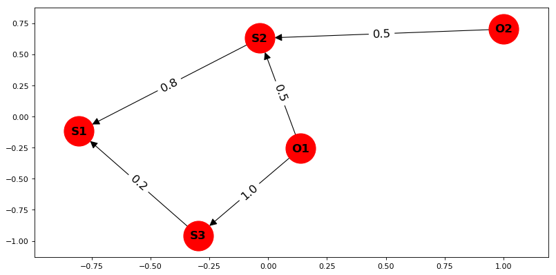

```python
G = nx.from_pandas_edgelist(data,'owner', 'shop', edge_attr = ('share'),
                            create_using=nx.DiGraph())
figure(num=None, figsize=(12, 6), dpi=80, facecolor='w', edgecolor='k')
np.random.seed(1)
pos=nx.spring_layout(G, k = 0.5, iterations = 20)
node_labels = {node:node for node in G.nodes()}
edge_labs = nx.get_edge_attributes(G,'share')
nx.draw_networkx(G, pos, labels = node_labels, arrowstyle = '-|>',
                 edge_labels = edge_labs,
             arrowsize = 20,  font_size = 15,
                 font_weight = 'bold', node_size = 1500)
nx.draw_networkx_edge_labels(G, pos, edge_labels = edge_labs,
                             font_size = 15)
```

Here in order to find the share that owner 1 has over shop 1, the 2 paths need to be multiplied and then added:

```python
from operator import mul
from functools import reduce

# Get all unique from each column
owners = set(data['owner'])
shops  = set(data['shop'])

# Open data frames
result = []
summary = {}

# Create loop
for shop in shops:
    for owner in owners:
        for path in nx.all_simple_paths(G, owner, shop):
            # Grab and add shares for all paths
            share = reduce(mul, (G[start][end]['share'] for start,
                                 end in zip(path[:-1], path[1:])), 1)
            summary[(shop, owner)] = summary.get((shop, owner), 0) + share

# Create final df
summary = pd.DataFrame.from_dict(summary, orient = 'index',
                                 columns = 'share'.split())
print(summary)
```

```
          share
(S3, O1)  1.0
(S2, O1)  0.5
(S2, O2)  0.5
(S1, S3)  0.2
(S1, O1)  0.6
(S1, S2)  0.8
(S1, O2)  0.4
```

This method will work for many different networks within the same data frame. The code multiplies through all paths and then adds together the results. I can turn this into final ownership in the same way as before:

```python
# Turn index to column
summary = summary.reset_index()

# Turn into 2 separate stripped columns
summary["index"] = summary["index"].astype(str)
summary['shop'], summary['owner'] = summary['index'].str.split(' ', 1).str
summary["shop"] = summary.shop.str.replace('\W', '')
summary["owner"] = summary.owner.str.replace('\W', '')

# Tunr into percentage and add to owners
summary["share"] = summary["owner"] + ": " + round(
    summary["share"]*100).map(str) + "%"

# Keep only final owners
summary = summary[summary.owner.str.startswith('O')]

# Final aggregation
summary = summary.sort_values(by = ["shop", "share"])
summary = pd.DataFrame(summary.groupby('shop')['share'].apply(list))
summary = summary.reset_index()
summary.head()
```

|  | shop | share |
| --- | --- | --- |
| 0 | S1 | [O1: 60.0%, O2: 40.0%] |
| 1 | S2 | [O1: 50.0%, O2: 50.0%] |
| 2 | S3 | [O1: 100.0%] |

Owner 1 has (100% x 20%) + (50% x 80%) = 60%. As a final example, I introduce a larger network with some more complicated loops.

```python
data = pd.DataFrame({
    'shop': ['S1','S1','S1','S1','S2','S2','S2','S3','S3','S3','S4','S4','S4',
             'S5','S5','S5','S6','S7','S7','S7','S8','S8','S8','S9','S9','S9',
             'S10','S10','S10','S10','S11','S11','S11','S11','S11','S12','S12',
             'S12','S13','S13','S13','S14','S14','S14','S15','S15','S15','S16',
             'S16','S16','S17','S17','S17'],
    'owner':['O1','O2','S2','S3','O1','S3','S4','O4','O3','O13','O2','O3','O4',
             'S3','O5','O6','O5','O5','O6','S7','S5','S7','O6','S5','S7','O7',
             'O7', 'O8', 'O9', 'O12', 'O8', 'O9','O10','O11','S10', 'O8','O11',
             'O12','O10','O11','O13','O9','O10','O13', 'O15','O16','O17','O13',
             'O15','S15','O14','O15','S16'],
    'share':[0.2, 0.2, 0.3, 0.3, 0.1, 0.5, 0.4, 0.15, 0.15, 0.7, 0.3, 0.3, 0.4,
            0.2, 0.3, 0.5, 1.0, 0.2, 0.2, 0.6, 0.1, 0.1, 0.8, 0.25, 0.25, 0.5,
            0.25, 0.25, 0.25, 0.25, 0.1,  0.2,  0.3,  0.15, 0.25,  0.3,  0.3,
            0.4,  0.2,  0.2,  0.6,  0.4,  0.5,  0.1, 0.4, 0.4, 0.2, 0.3,
            0.3, 0.4, 0.2, 0.2, 0.6]})
data.head()
```

|  | shop | owner | share |
| --- | --- | --- | --- |
| 0 | S1 | O1 | 0.2 |
| 1 | S1 | O2 | 0.2 |
| 2 | S1 | S2 | 0.3 |
| 3 | S1 | S3 | 0.3 |
| 4 | S2 | O1 | 0.1 |

And draw the network:

[output not shown]

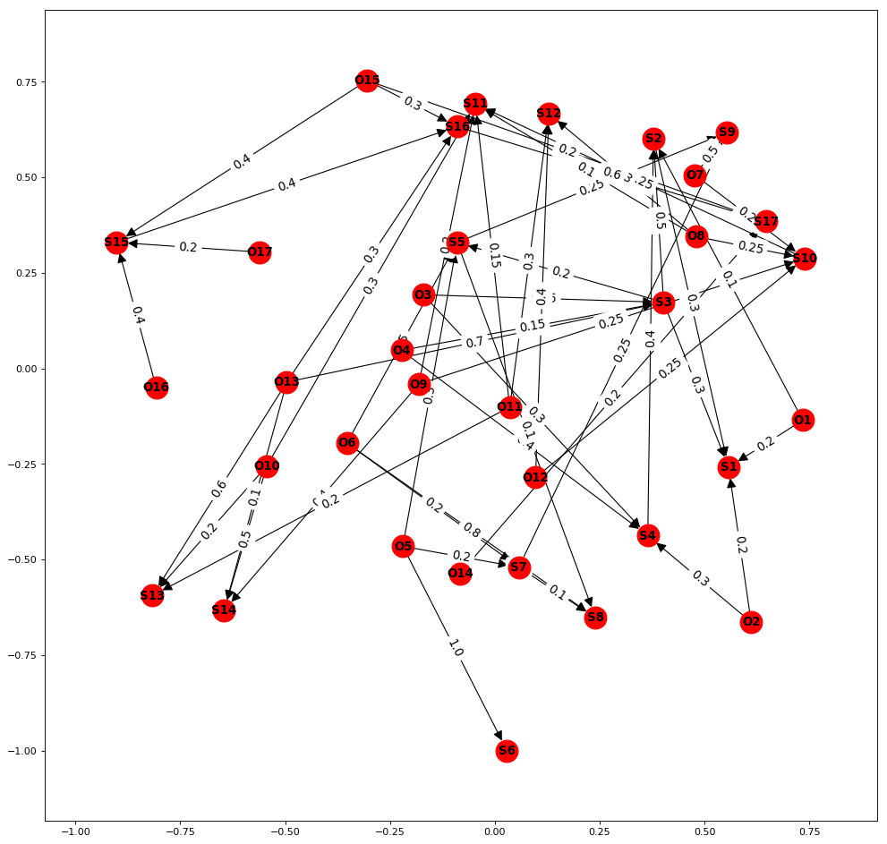

```python
G = nx.from_pandas_edgelist(data,'owner', 'shop',
                            edge_attr = ('share'),
                            create_using=nx.DiGraph())
figure(num=None, figsize=(15, 15), dpi=80, facecolor='w', edgecolor='k')
np.random.seed(2019)
pos=nx.spring_layout(G, k = 0.5, iterations = 20)
node_labels = {node:node for node in G.nodes()}
edge_labs = nx.get_edge_attributes(G,'share')
nx.draw_networkx(G, pos, labels = node_labels, arrowstyle = '-|>',
                 edge_labels = edge_labs,
             arrowsize = 20,  font_size = 12,
                 font_weight = 'bold', node_size = 500)
nx.draw_networkx_edge_labels(G, pos, edge_labels = edge_labs,
                             font_size = 12)
```

The network looks extremely complicated but the code can still find the owners of the network:

```python
# Get all unique from each column
owners = set(data['owner'])
shops  = set(data['shop'])

# Open data frames
result = []
summary = {}

# Create loop
for shop in shops:
    for owner in owners:
        for path in nx.all_simple_paths(G, owner, shop):
            # Grab and add shares for all paths
            share = reduce(mul, (G[start][end]['share'] for start,
                                 end in zip(path[:-1], path[1:])), 1)
            summary[(shop, owner)] = summary.get((shop, owner), 0) + share

# Create final df
summary = pd.DataFrame.from_dict(summary, orient = 'index',
                                 columns = 'share'.split())
summary.head(10)
```

|  | share |
| --- | --- |
| (S2, O13) | 0.350 |
| (S2, S4) | 0.400 |
| (S2, O4) | 0.235 |
| (S2, O2) | 0.120 |
| (S2, O1) | 0.100 |
| (S2, O3) | 0.195 |
| (S2, S3) | 0.500 |
| (S8, O13) | 0.014 |
| (S8, S7) | 0.100 |
| (S8, O5) | 0.050 |

Finally, turn into a proper data frame and print, like before:

```python
# Turn index to column
summary = summary.reset_index()

# Turn into 2 separate stripped columns
summary["index"] = summary["index"].astype(str)
summary['shop'], summary['owner'] = summary['index'
                                           ].str.split(' ', 1).str
summary["shop"] = summary.shop.str.replace('\W', '')
summary["owner"] = summary.owner.str.replace('\W', '')

# Tunr into percentage and add to owners
summary["share"] = summary["owner"] + ": " + round(
    summary["share"]*100,5).map(str) + "%"

# Keep only final owners
summary = summary[summary.owner.str.startswith('O')]

# Final aggregation
summary = summary.sort_values(by = ["shop", "share"])
summary = pd.DataFrame(summary.groupby('shop')['share'].apply(list))
summary = summary.reset_index()
summary.head(20)
```

|  | shop | share |
| --- | --- | --- |
| 0 | S1 | [O13: 31.5%, O1: 23.0%, O2: 23.6%, O3: 10.35%, O4: 11.55%] |
| 1 | S10 | [O12: 25.0%, O7: 25.0%, O8: 25.0%, O9: 25.0%] |
| 2 | S11 | [O10: 30.0%, O11: 15.0%, O12: 6.25%, O7: 6.25%, O8: 16.25%, O9: 26.25%] |
| 3 | S12 | [O11: 30.0%, O12: 40.0%, O8: 30.0%] |
| 4 | S13 | [O10: 20.0%, O11: 20.0%, O13: 60.0%] |
| 5 | S14 | [O10: 50.0%, O13: 10.0%, O9: 40.0%] |
| 6 | S15 | [O15: 40.0%, O16: 40.0%, O17: 20.0%] |
| 7 | S16 | [O13: 30.0%, O15: 46.0%, O16: 16.0%, O17: 8.0%] |
| 8 | S17 | [O13: 18.0%, O14: 20.0%, O15: 47.6%, O16: 9.6%, O17: 4.8%] |
| 9 | S2 | [O13: 35.0%, O1: 10.0%, O2: 12.0%, O3: 19.5%, O4: 23.5%] |
| 10 | S3 | [O13: 70.0%, O3: 15.0%, O4: 15.0%] |
| 11 | S4 | [O2: 30.0%, O3: 30.0%, O4: 40.0%] |
| 12 | S5 | [O13: 14.0%, O3: 3.0%, O4: 3.0%, O5: 30.0%, O6: 50.0%] |
| 13 | S6 | [O5: 100.0%] |
| 14 | S7 | [O5: 20.0%, O6: 20.0%] |
| 15 | S8 | [O13: 1.4%, O3: 0.3%, O4: 0.3%, O5: 5.0%, O6: 87.0%] |
| 16 | S9 | [O13: 3.5%, O3: 0.75%, O4: 0.75%, O5: 12.5%, O6: 17.5%, O7: 50.0%] |